# Customer Lifetime Value Analysis Report

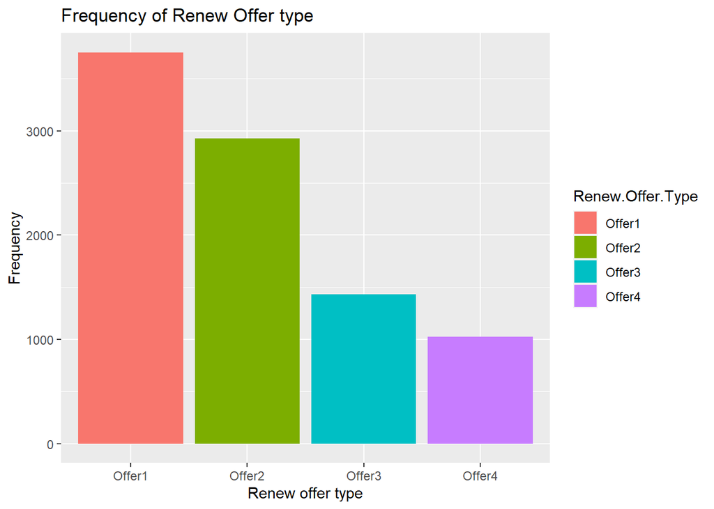

```r
options(repr.plot.width=7, repr.plot.height=4)
GraphRenewOff <- ggplot(data, aes(x=Renew.Offer.Type, fill = Renew.Offer.Type)) +
geom_bar(stat = "count")+
  labs(title="Frequency of Renew Offer type",
       x="Renew offer type",
       y="Frequency")
GraphRenewOff
```

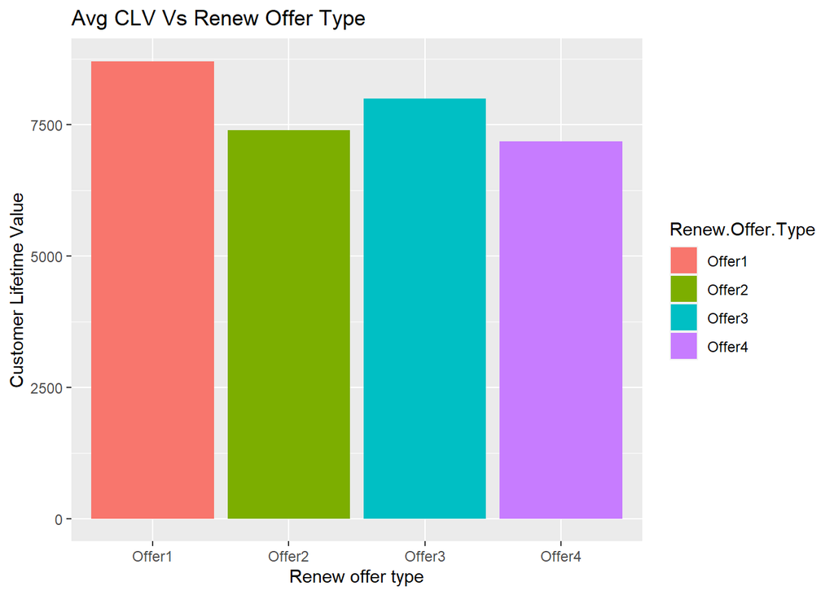

```
Most Customers accepted renewal offer type1 and they are more valuable compared to other customers who choose the remaining offers.
```

```r
options(repr.plot.width=7, repr.plot.height=4)
GraphRenewOff <- ggplot(data, aes(x=Renew.Offer.Type, y=Customer.Lifetime.Value, fill = Renew.Offer.Type)) +
geom_bar(stat = "summary",fun="mean")+
  labs(title="Avg CLV Vs Renew Offer Type",
       x="Renew offer type",
       y="Customer Lifetime Value")
GraphRenewOff
```

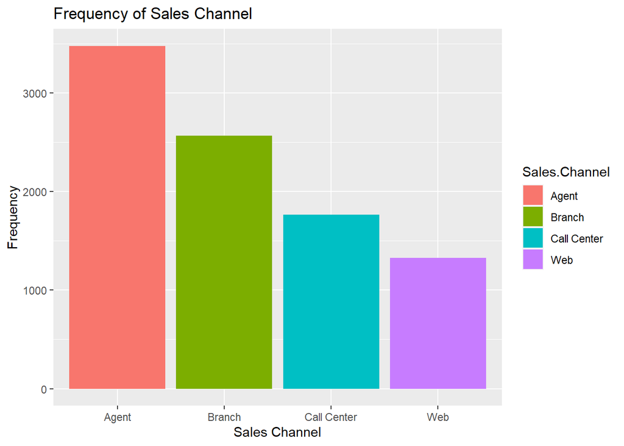

```r
options(repr.plot.width=7, repr.plot.height=4)
GraphSalesCh <- ggplot(data, aes(x=Sales.Channel, fill = Sales.Channel)) +
geom_bar(stat = "count")+
  labs(title="Frequency of Sales Channel",
       x="Sales Channel",
       y="Frequency")


GraphSalesCh
```

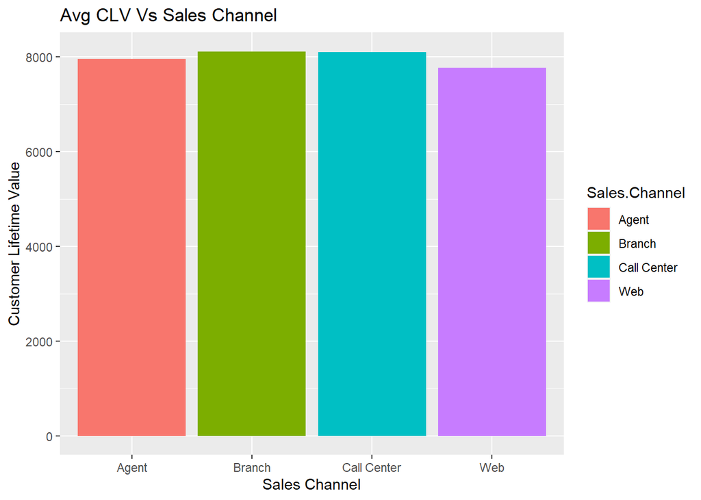

```
Good proportion of customers got in because of agents.
But their CLV is not significantly influenced by the sales channel.
```

```r
options(repr.plot.width=7, repr.plot.height=4)
GraphSalesCh <- ggplot(data, aes(x=Sales.Channel, y=Customer.Lifetime.Value, fill = Sales.Channel)) +
geom_bar(stat = "summary",fun="mean")+
  labs(title="Avg CLV Vs Sales Channel",x="Sales Channel",y="Customer Lifetime Value")

GraphSalesCh
```

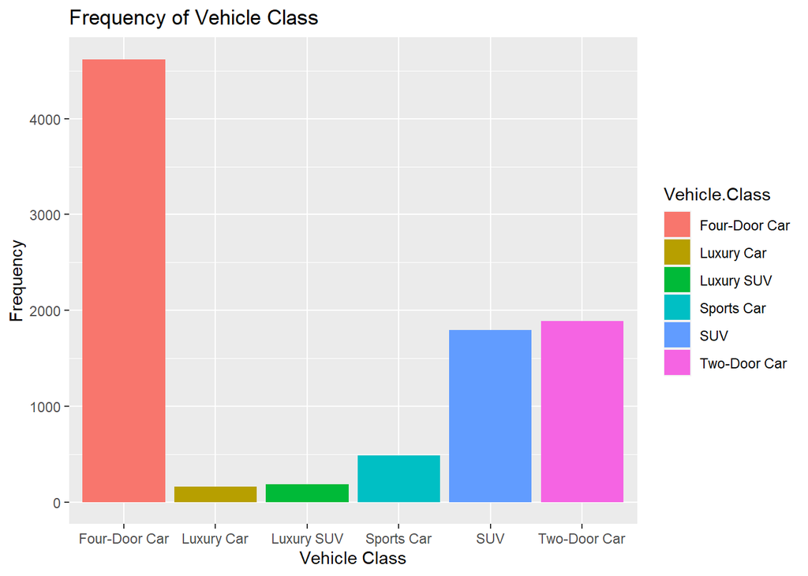

```
Most Customers had taken policy for Four-Door-Cars.
```

```r
options(repr.plot.width=7, repr.plot.height=4)
GraphVecClass <- ggplot(data, aes(x=Vehicle.Class,  fill = Vehicle.Class)) +
geom_bar(stat = "count")+
  labs(title="Frequency of Vehicle Class",
       x="Vehicle Class",
       y="Frequency")
GraphVecClass
```

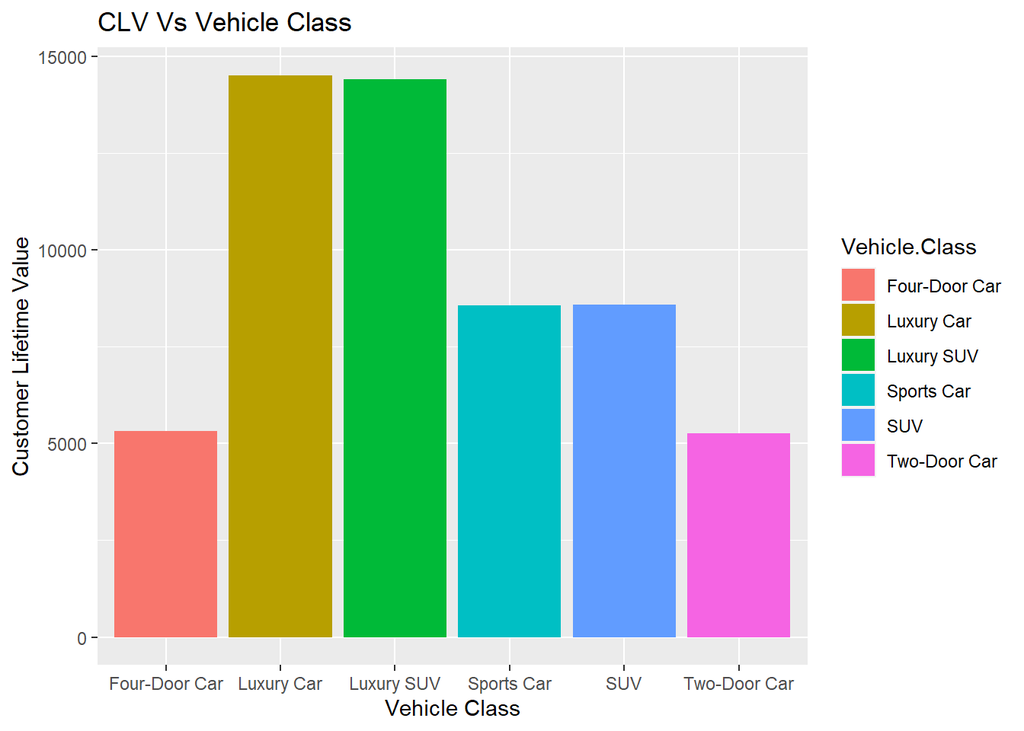

```
But Customers who took policy for Luxury Car and Luxury SUV are expected to be more valuable compared to the rest. This is likely because the higher is the value of the vehicles, higher the value of the policy.
```

```r
options(repr.plot.width=20, repr.plot.height=4)
GraphVecClass <- ggplot(data, aes(x=Vehicle.Class, y=Customer.Lifetime.Value, fill = Vehicle.Class)) +
geom_bar(stat = "summary",fun="median")+
  labs(title="CLV Vs Vehicle Class",
       x="Vehicle Class",
       y="Customer Lifetime Value")
GraphVecClass
```

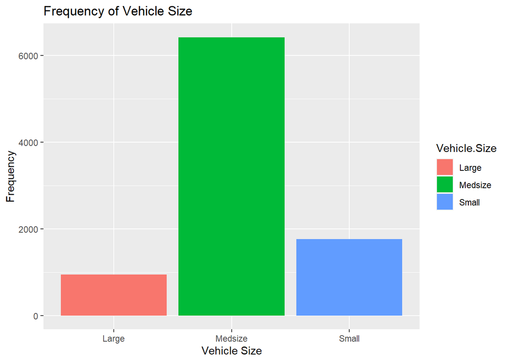

```r
options(repr.plot.width=7, repr.plot.height=4)
GraphVecSize <- ggplot(data, aes(x=Vehicle.Size, fill = Vehicle.Size)) +
geom_bar(stat = "count")+
  labs(title="Frequency of Vehicle Size",
       x="Vehicle Size",
       y="Frequency")

GraphVecSize
```

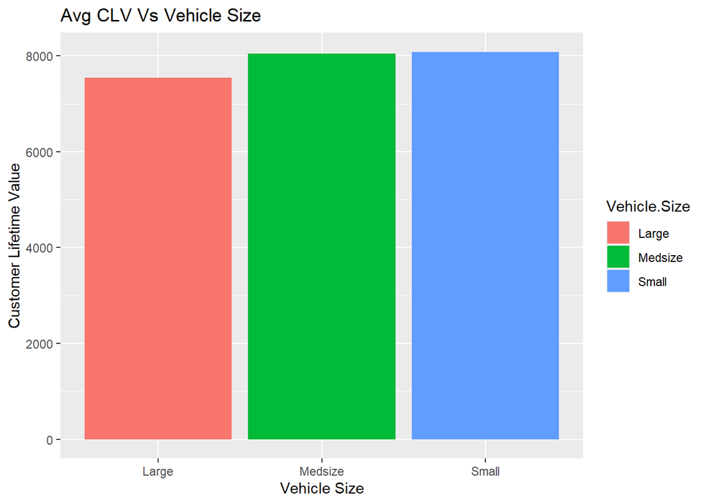

```
Midsize vehicles were more owned by the customers.
Vehicle size doesn't influence much on their Customer Lifetime Value.
```

```r
options(repr.plot.width=7, repr.plot.height=4)
GraphVecSize <- ggplot(data, aes(x=Vehicle.Size, y=Customer.Lifetime.Value, fill = Vehicle.Size)) +
geom_bar(stat = "summary",fun="mean")+
  labs(title="Avg CLV Vs Vehicle Size",
       x="Vehicle Size",
       y="Customer Lifetime Value")

GraphVecSize
```

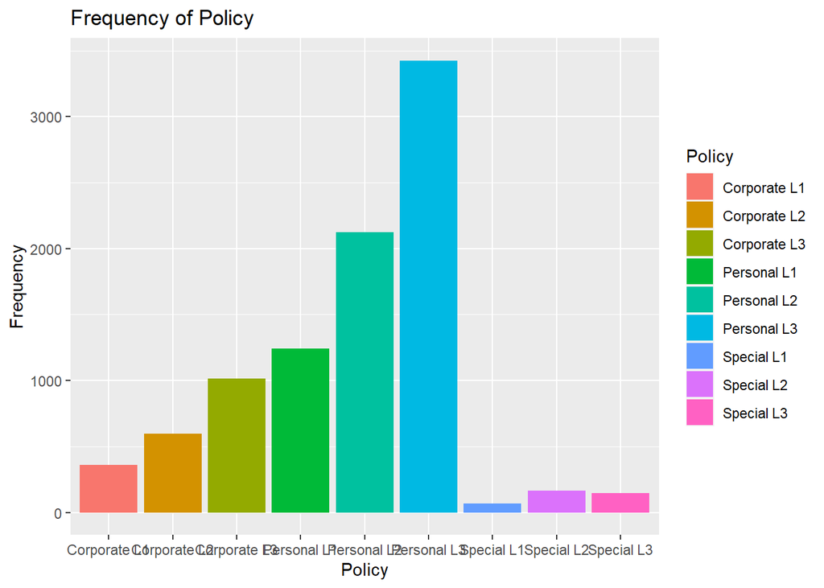

```r
options(repr.plot.width=9, repr.plot.height=4)
GraphPolicy <- ggplot(data, aes(x=Policy, fill = Policy)) +
geom_bar(stat = "count")+
  labs(title="Frequency of Policy",
       y="Frequency")

GraphPolicy
```

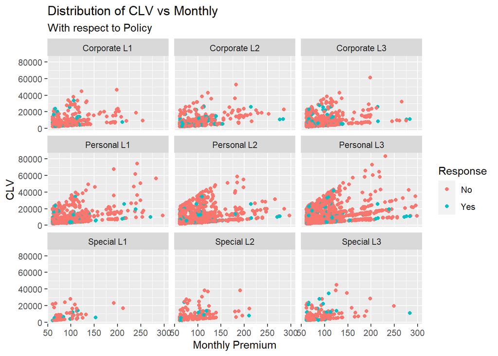

```r
#With respect to Monthly Auto
ggplot(data=data, aes(y=Customer.Lifetime.Value, x=Monthly.Premium.Auto, color=Response ))+
  geom_point()+
  facet_wrap(~Policy)+
  labs(title="Distribution of CLV vs Monthly",
       subtitle="With respect to Policy",
       fill="Response",
       y="CLV",
       x="Monthly Premium")
```

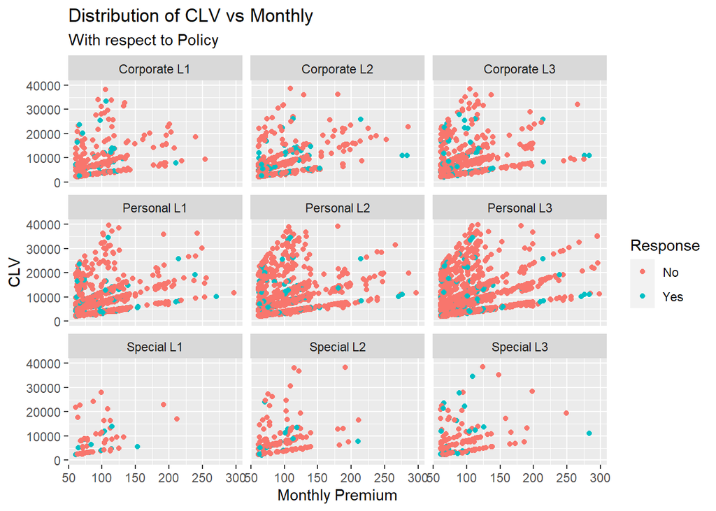

```
Customers who adopted Personal policy plan are more and  L3 category is chosen highly among all the policy types.
```

```r
#With respect to Policy
ggplot(data=data, aes(y=Customer.Lifetime.Value, x=Monthly.Premium.Auto, color=Response ))+
  geom_point()+
  ylim(c(0,40000))+
  facet_wrap(~Policy)+
  labs(title="Distribution of CLV vs Monthly",
       subtitle="With respect to Policy",
       fill="Response",
       y="CLV",
       x="Monthly Premium")
```

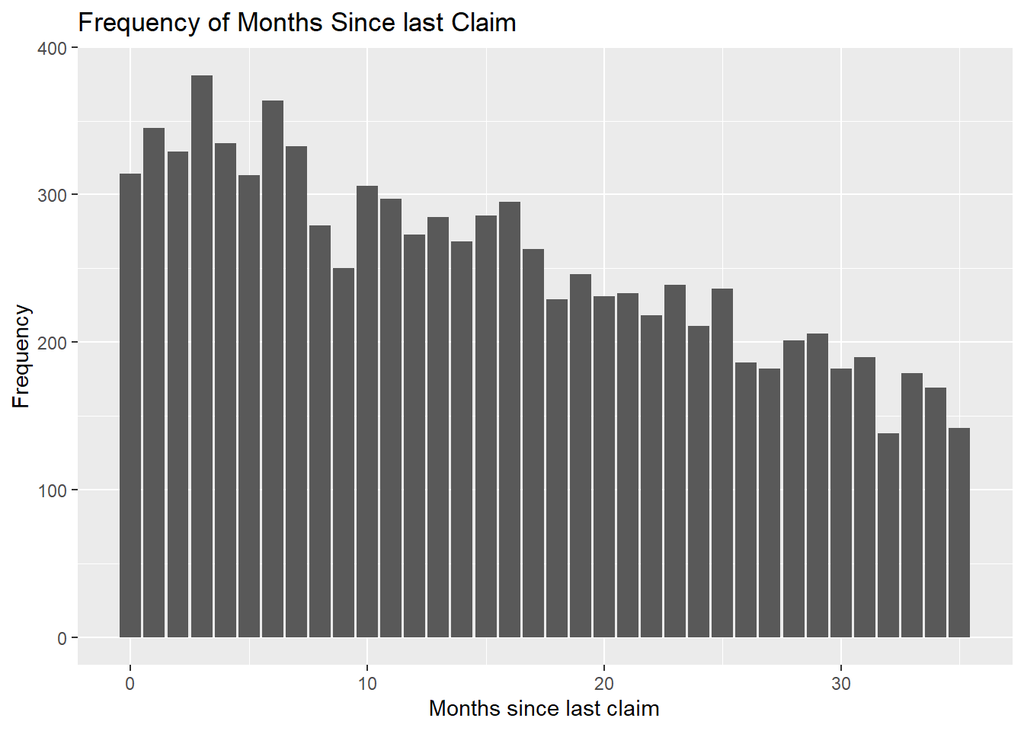

```
From the graph, more customers made their claims recently.
```

```r
options(repr.plot.width=7, repr.plot.height=4)
GraphMonthsClaim <- ggplot(data, aes(x=Months.Since.Last.Claim, fill = Months.Since.Last.Claim))+
geom_bar(stat = "count")+
  labs(title="Frequency of Months Since last Claim",
       x="Months since last claim",
       y="Frequency")

GraphMonthsClaim
```

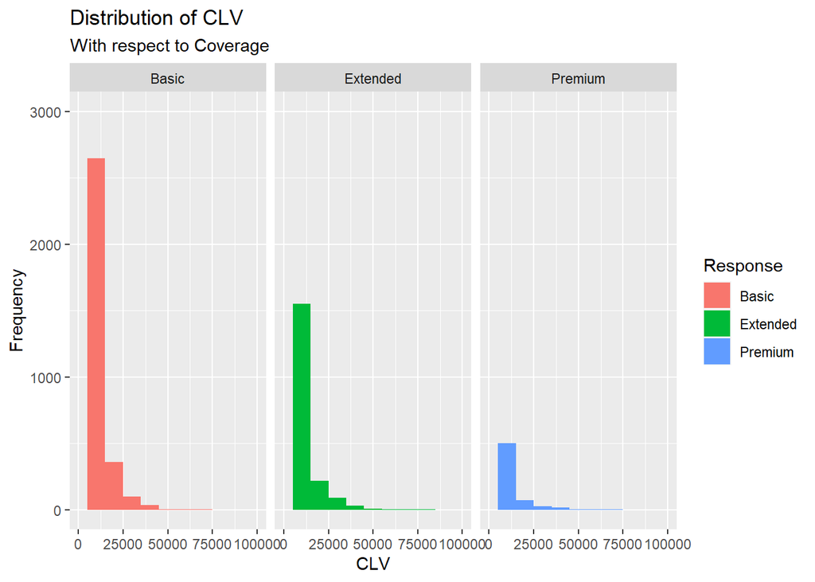

```r
#Distribution of CLV with respect to Coverage
ggplot(data=data, aes(x=Customer.Lifetime.Value, fill=Coverage))+
  stat_bin(binwidth=10000,  position="dodge")+
  ylim(c(0,3000))+
  xlim(c(0,100000))+
  facet_wrap(~Coverage)+
  labs(title="Distribution of CLV",
       subtitle="With respect to Coverage",
       fill="Response",
       x="CLV",
       y="Frequency")
```

The distribution of CLV is more or less same.

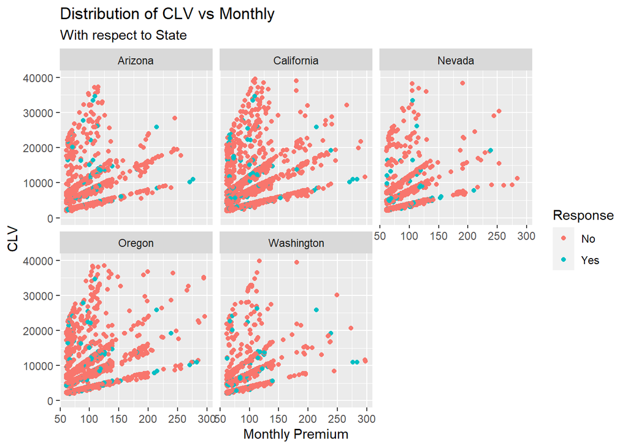

```r
#With respect to State
ggplot(data=data, aes(y=Customer.Lifetime.Value, x=Monthly.Premium.Auto, color=Response ))+
  geom_point()+
  ylim(c(0,40000))+
  facet_wrap(~State)+
  labs(title="Distribution of CLV vs Monthly",
       subtitle="With respect to State",
       fill="Response",
       y="CLV",
       x="Monthly Premium")
```

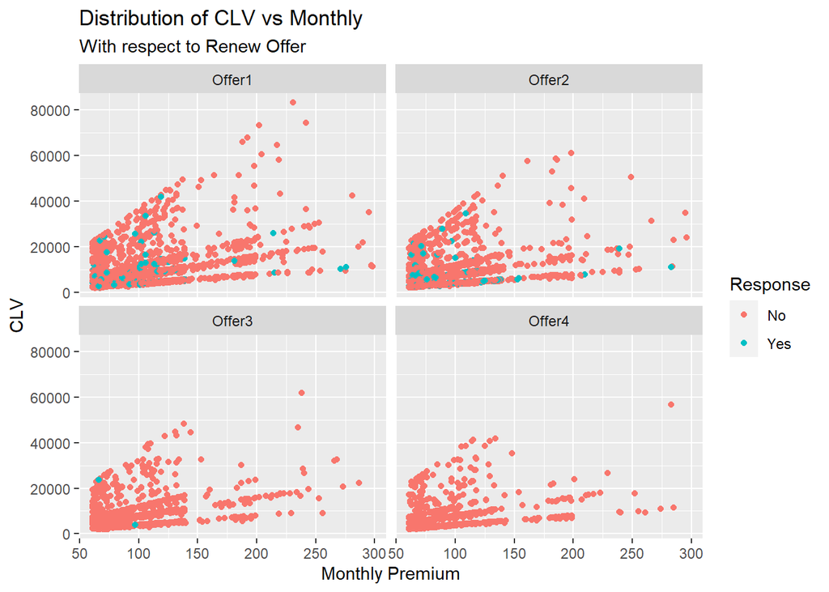

```
There is a lack of positive response in offer type 4.
```

```r
#With respect to Renew Offer

ggplot(data=data, aes(y=Customer.Lifetime.Value, x=Monthly.Premium.Auto, color=Response ))+
  geom_point()+
  facet_wrap(~Renew.Offer.Type)+
  labs(title="Distribution of CLV vs Monthly",
       subtitle="With respect to Renew Offer",
       fill="Response",
       y="CLV",
       x="Monthly Premium")
```

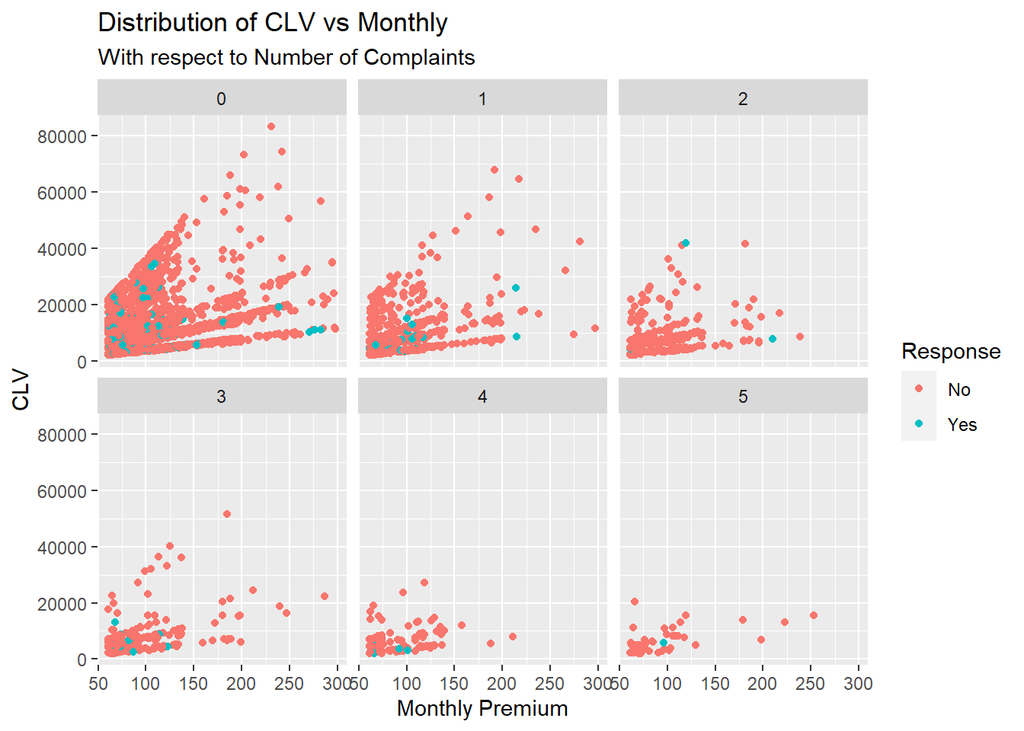

```
As the number of complaints increases, we can see that those customers are expected to be less valuable.
```

```r
ggplot(data=data, aes(y=Customer.Lifetime.Value, x=Monthly.Premium.Auto, color=Response ))+
  geom_point()+
  facet_wrap(~Number.of.Open.Complaints)+
  labs(title="Distribution of CLV vs Monthly",
       subtitle="With respect to Number of Complaints",
       fill="Response",
       y="CLV",
       x="Monthly Premium")
```

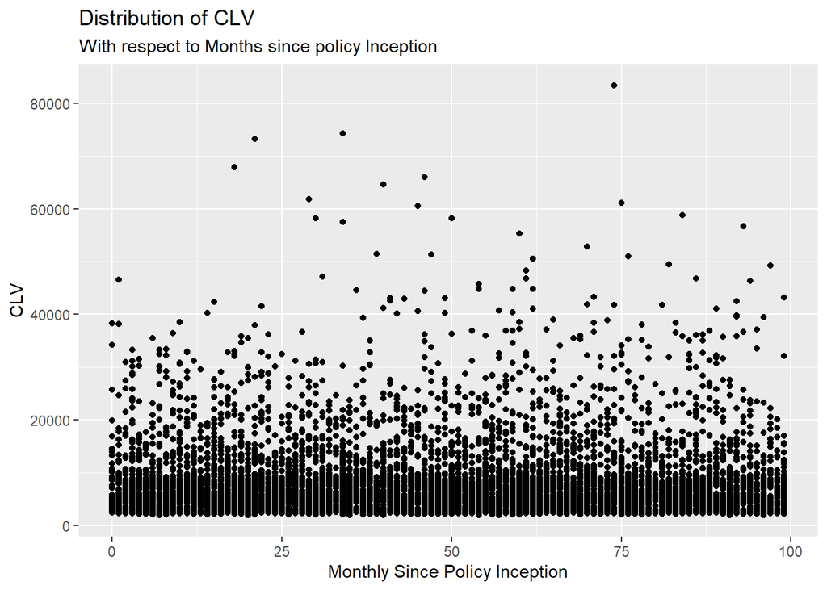

```r
ggplot(data=data, aes(y=Customer.Lifetime.Value, x=Months.Since.Policy.Inception ))+
  geom_point()+
  labs(title="Distribution of CLV",
       subtitle="With respect to Months since policy Inception",
       fill="Response",
       y="CLV",
       x="Monthly Since Policy Inception")
```

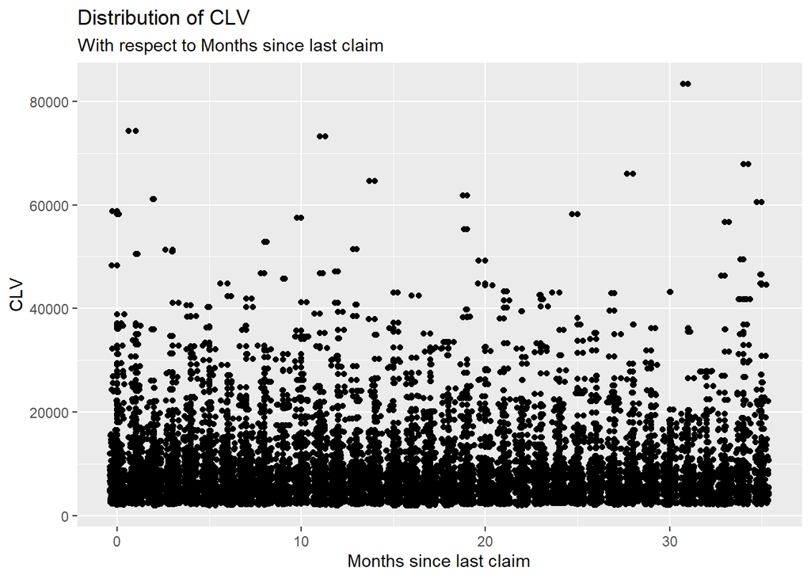

```
There doesnt seem to be any correlation between monthS since last claim and CLV.
```

```r
ggplot(data=data, aes(y=Customer.Lifetime.Value, x=Months.Since.Last.Claim ))+
  geom_point()+
  geom_jitter()+
  labs(title="Distribution of CLV",
       subtitle="With respect to Months since last claim",
       fill="Response",
       y="CLV",
       x="Months since last claim")
```

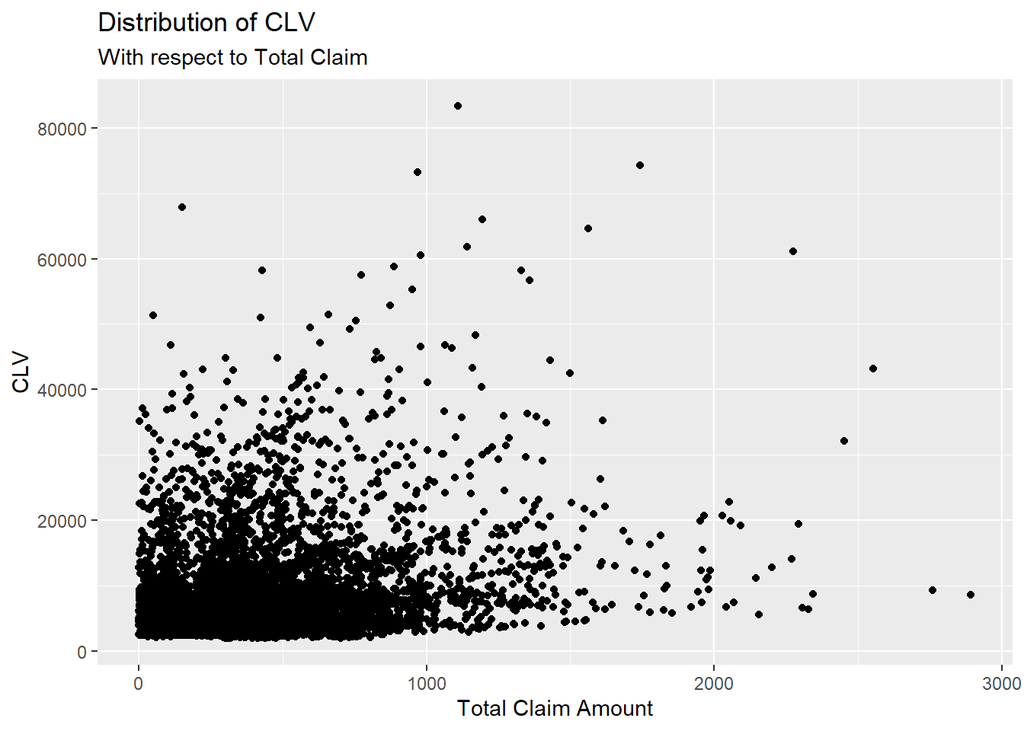

```r
ggplot(data=data, aes(y=Customer.Lifetime.Value, x=Total.Claim.Amount ))+
  geom_point()+
  labs(title="Distribution of CLV",
       subtitle="With respect to Total Claim",
       fill="Response",
       y="CLV",
       x="Total Claim Amount")
```

## Feature Engineering

Here we are going to select the significant features from the raw data and using it for predicting models.

##### CONVERTING TO FACTORS

```r
data$State <- factor(data$State)
data$Response <- factor(data$Response)
data$Coverage <- factor(data$Coverage,
                        levels=c('Basic','Extended','Premium'))
data$Education <- factor(data$Education,
                         levels=c('High School or Below','College','Bachelor',
                                  'Master','Doctor'))
data$EmploymentStatus <- factor(data$EmploymentStatus)
data$Gender <- factor(data$Gender)
data$Marital.Status <- factor(data$Marital.Status)
data$Number.of.Policies <- factor(data$Number.of.Policies)
data$Policy.Type <- factor(data$Policy.Type)
data$Policy <- factor(data$Policy)
data$Renew.Offer.Type <- factor(data$Renew.Offer.Type)
data$Sales.Channel <- factor(data$Sales.Channel)
data$Vehicle.Class <- factor(data$Vehicle.Class)
data$Vehicle.Size <- factor(data$Vehicle.Size,
                            levels=c('Small','Medsize','Large'))
```

```r
df <- data[,-c(1,7)]   # SELECTING THE COLUMNS EXCEPT 'CUSTOMER ID' AND 'EFFECT TO DATE'
```

```r
str(df)
```

```
## 'data.frame':    9134 obs. of  22 variables:
##  $ State                        : Factor w/ 5 levels "Arizona","California",..: 5 1 3 2 5 4 4 1 4 4 ...
##  $ Customer.Lifetime.Value      : num  2764 6980 12887 7646 2814 ...
##  $ Response                     : Factor w/ 2 levels "No","Yes": 1 1 1 1 1 2 2 1 2 1 ...
##  $ Coverage                     : Factor w/ 3 levels "Basic","Extended",..: 1 2 3 1 1 1 1 3 1 2 ...
##  $ Education                    : Factor w/ 5 levels "High School or Below",..: 3 3 3 3 3 3 2 4 3 2 ...
##  $ EmploymentStatus             : Factor w/ 5 levels "Disabled","Employed",..: 2 5 2 5 2 2 2 5 3 2 ...
##  $ Gender                       : Factor w/ 2 levels "F","M": 1 1 1 2 2 1 1 2 2 1 ...
##  $ Income                       : int  56274 0 48767 0 43836 62902 55350 0 14072 28812 ...
##  $ Location.Code                : chr  "Suburban" "Suburban" "Suburban" "Suburban" ...
##  $ Marital.Status               : Factor w/ 3 levels "Divorced","Married",..: 2 3 2 2 3 2 2 3 1 2 ...
##  $ Monthly.Premium.Auto         : int  69 94 108 106 73 69 67 101 71 93 ...
##  $ Months.Since.Last.Claim      : int  32 13 18 18 12 14 0 0 13 17 ...
##  $ Months.Since.Policy.Inception: int  5 42 38 65 44 94 13 68 3 7 ...
##  $ Number.of.Open.Complaints    : int  0 0 0 0 0 0 0 0 0 0 ...
##  $ Number.of.Policies           : Factor w/ 9 levels "1","2","3","4",..: 1 8 2 7 1 2 9 4 2 8 ...
##  $ Policy.Type                  : Factor w/ 3 levels "Corporate Auto",..: 1 2 2 1 2 2 1 1 1 3 ...
##  $ Policy                       : Factor w/ 9 levels "Corporate L1",..: 3 6 6 2 4 6 3 3 3 8 ...
##  $ Renew.Offer.Type             : Factor w/ 4 levels "Offer1","Offer2",..: 1 3 1 1 1 2 1 1 1 2 ...
##  $ Sales.Channel                : Factor w/ 4 levels "Agent","Branch",..: 1 1 1 3 1 4 1 1 1 2 ...
##  $ Total.Claim.Amount           : num  385 1131 566 530 138 ...
##  $ Vehicle.Class                : Factor w/ 6 levels "Four-Door Car",..: 6 1 6 5 1 6 1 1 1 1 ...
##  $ Vehicle.Size                 : Factor w/ 3 levels "Small","Medsize",..: 2 2 2 2 2 2 2 2 2 2 ...
```

```r
set.seed(123)
sample <- sample(c(TRUE, FALSE),
                 nrow(df),
                 replace = T,
                 prob = c(0.6,0.4))
df.train <- df[sample, ]
df.test <- df[!sample, ]
```

# VARIOUS MODELS AND THEIR PERFORMANCE GRAPH

#### MODEL 1

Using multiple linear regression model to test the dependent variable clv with ‘all other variables’. The fit of the model is assessed through r-squared value, which represents the proportion of variance explained. Here adjusted R2 = 0.6407 and R2 = 0.6443.

```r
rsquare(model1,df.train)
```

```
## [1] 0.644263
```

```r
rsquare(model1,df.test)
```

```
## [1] 0.6225141
```

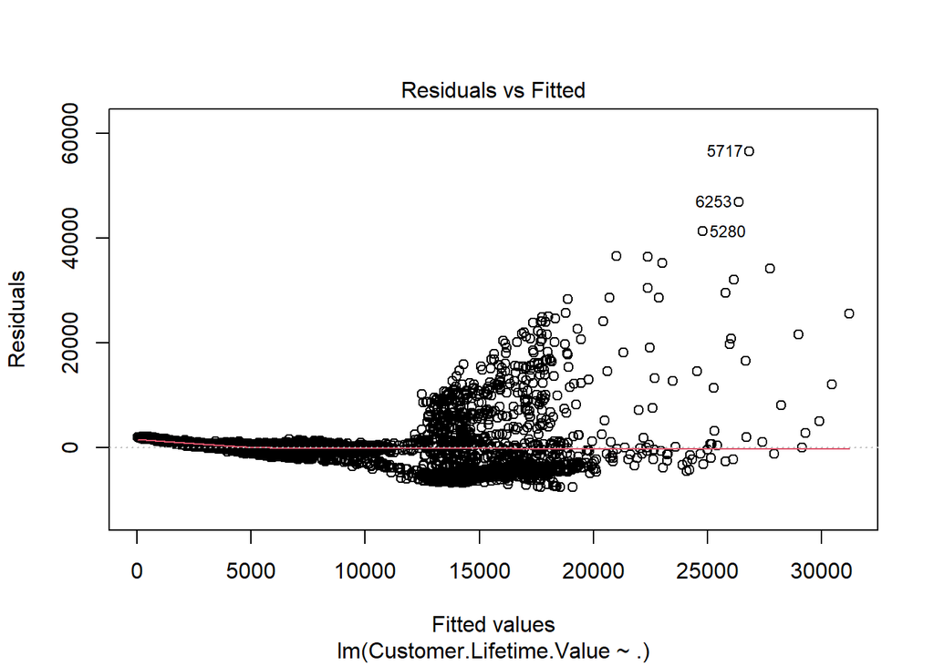

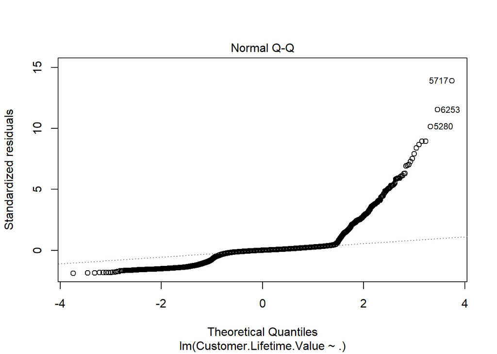

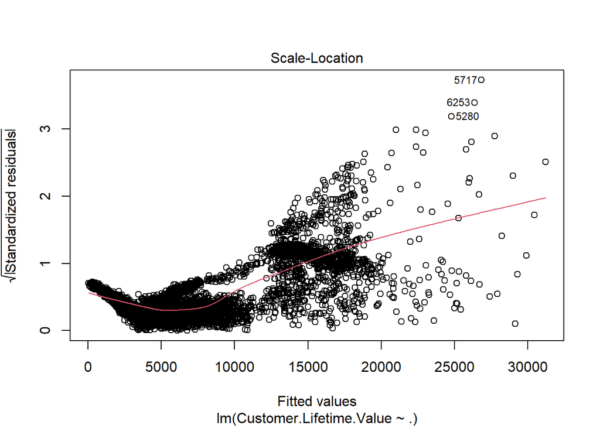

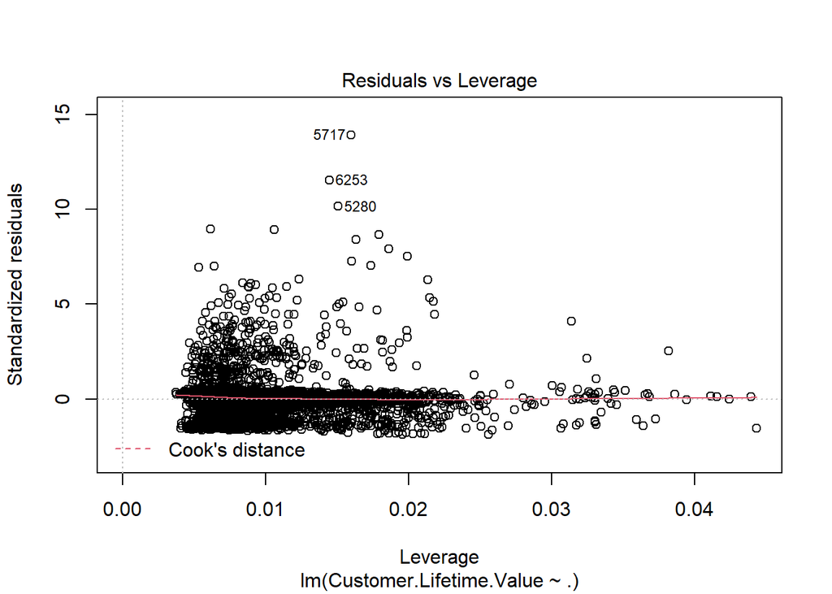

```r
plot(model1)
```

#### MODEL 2

Here, we used AIC as the criterion to select the variables and got an adjusted R squared value of 0.6415.

###### Features Selected -

- Response
- Education
- Employment Status
- Gender
- Marital.Status
- Monthly.Premium.Auto
- Months.Since.Last.Claim
- Number.of.Open.Complaints
- Number.of.Policies
- Vehicle.Class

```r
rsquare(model2,df.train)
```

```
## [1] 0.6432782
```

```r
rsquare(model2,df.test)
```

```
## [1] 0.6230048
```

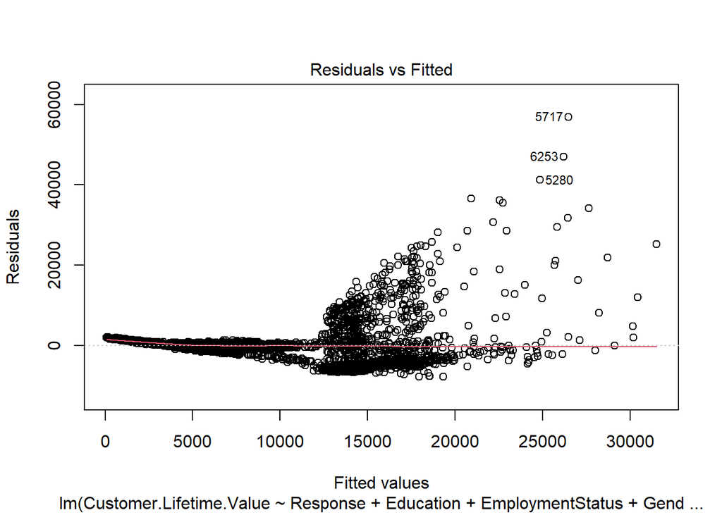

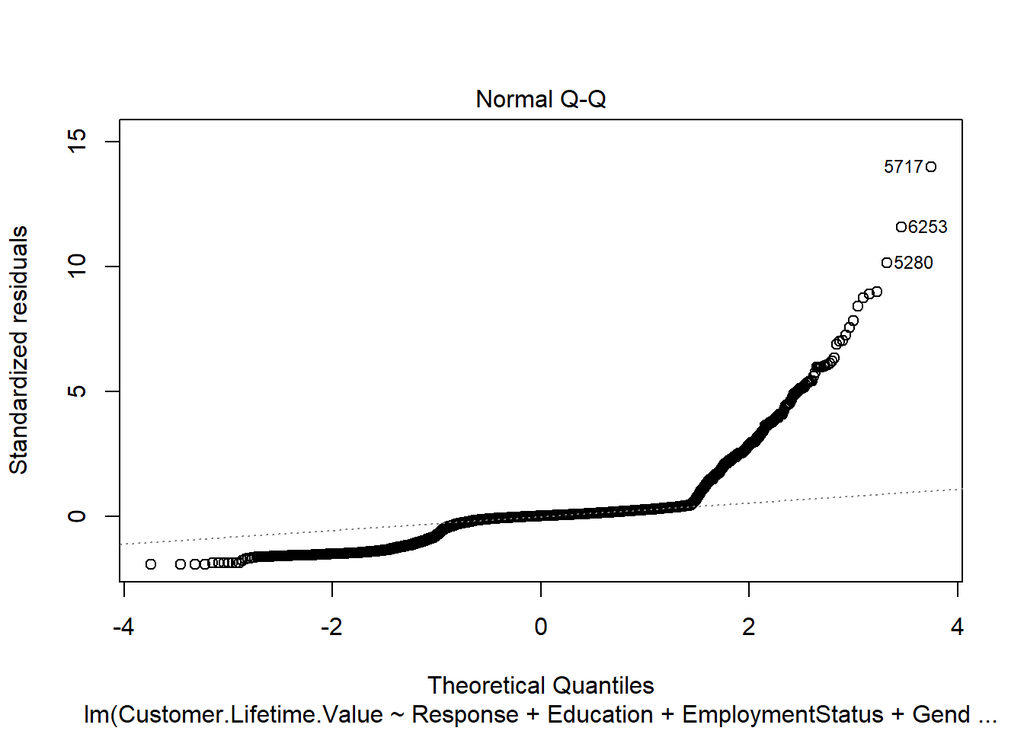

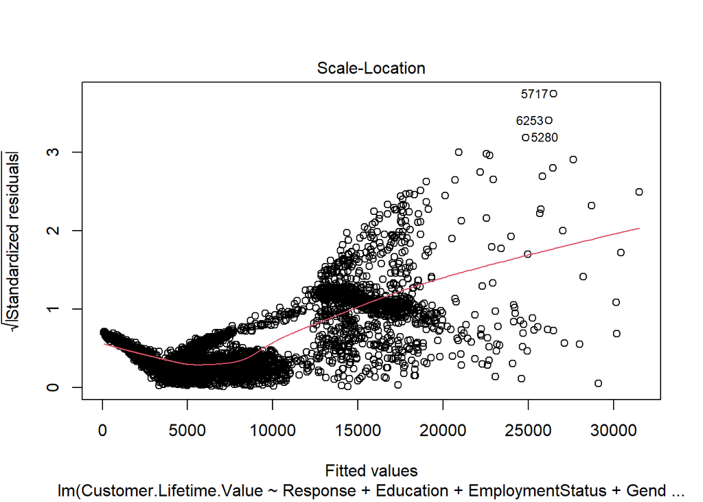

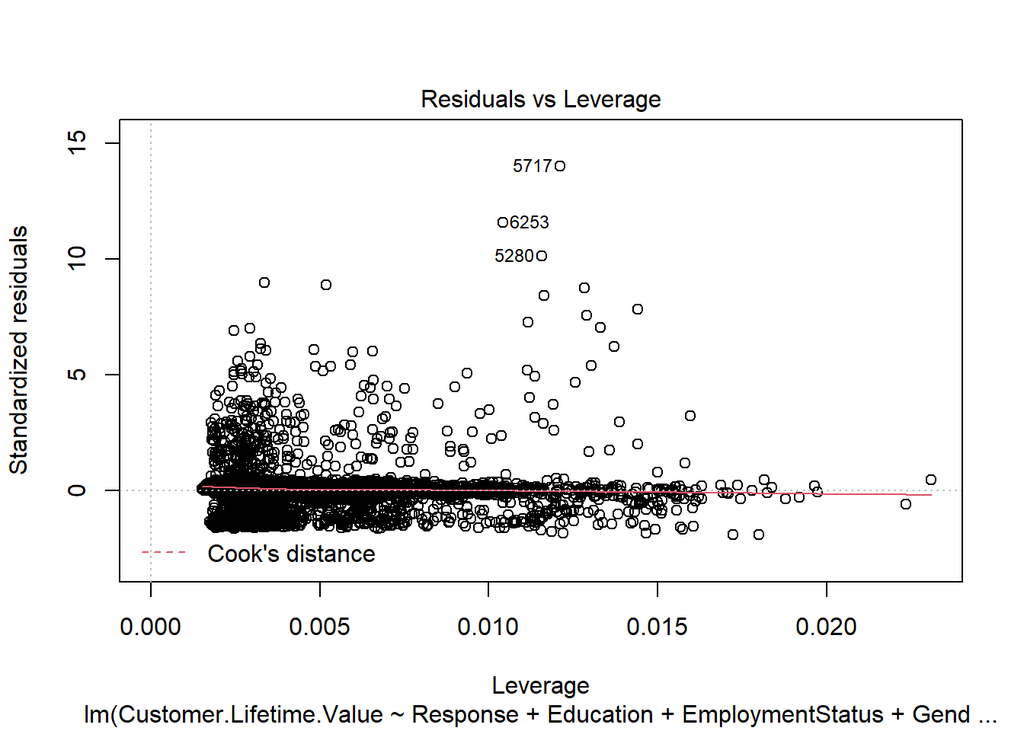

```r
plot(model2)
```

#### MODEL 3 #### Log Transformation

Using log transformation to treat outliers in variables like clv and monthly premium auto.

###### Features Selected -

- Response
- Education
- Employment Status
- Gender
- Marital.Status
- log1p(Monthly.Premium.Auto)
- Months.Since.Last.Claim
- Number.of.Open.Complaints
- Number.of.Policies
- Vehicle.Class

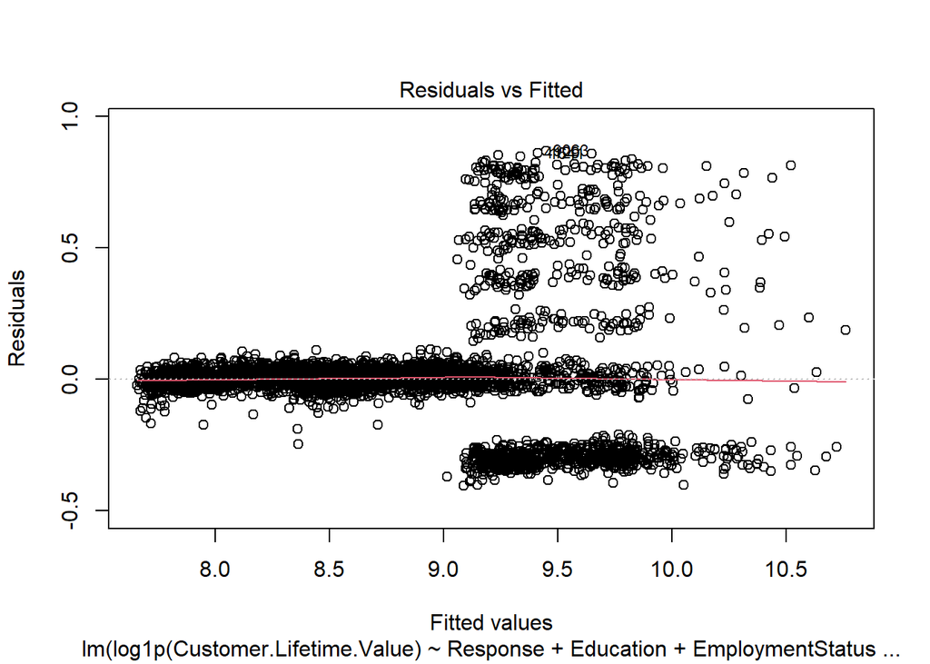

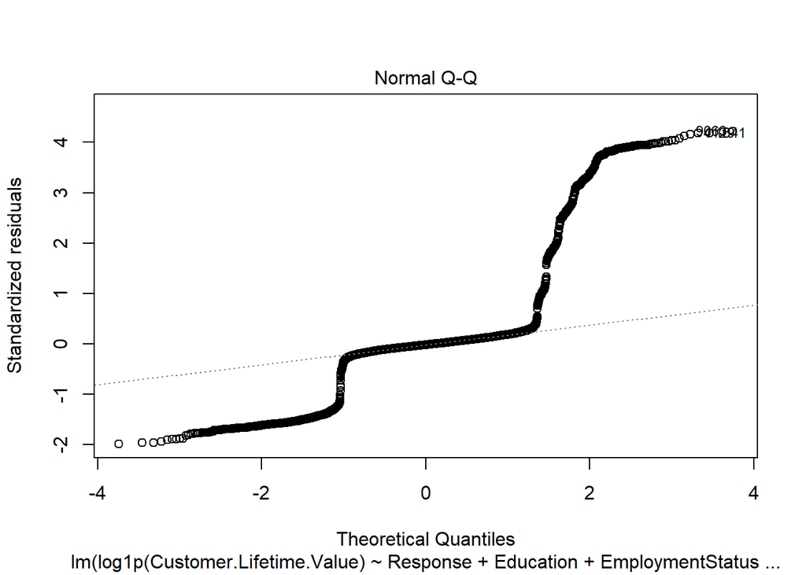

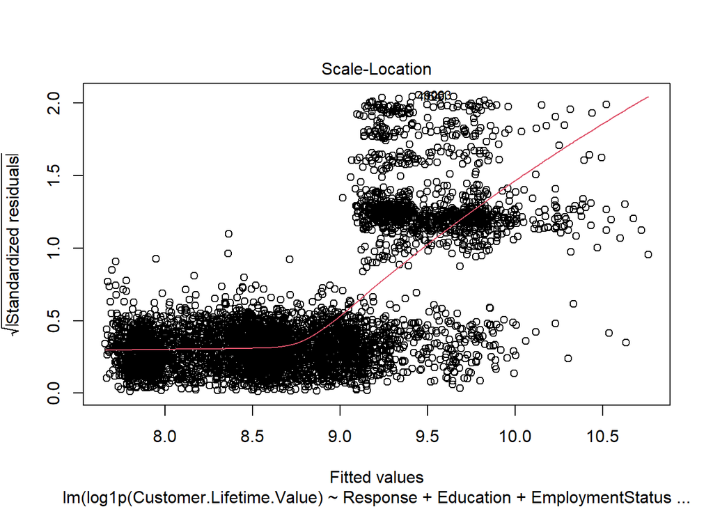

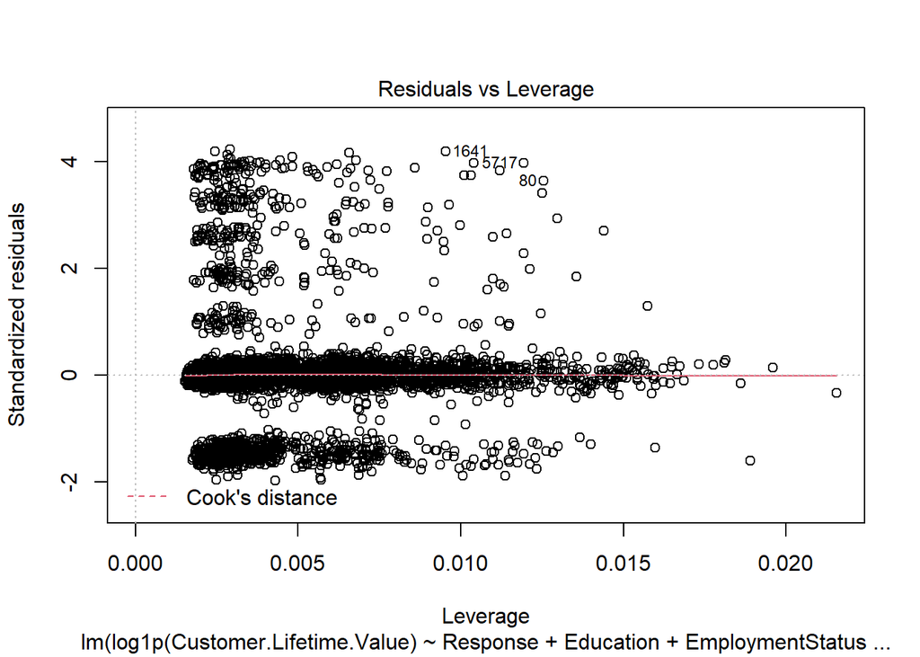

```r
plot(model3)
```

#### MODEL 4

#### CAPPING/CLIPPING TRANSFORMATION

Another outlier treatment, the clipping method is done on the dependent variable. Then the linear model results an adjusted R squared value of 0.6874. This is higher than our base model, suggesting clipping method does a better job in explaining the variance in clv.

###### Features Selected -

- All variables from model2, also Monthly premium auto was capped.

```r
rsquare(model4,df.train)
```

```
## [1] 0.6890013
```

```r
rsquare(model4,df.test)
```

```
## [1] 0.6203611
```

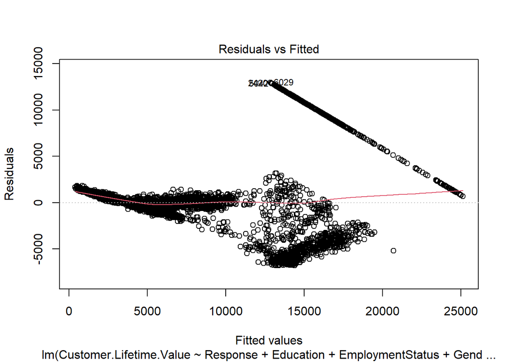

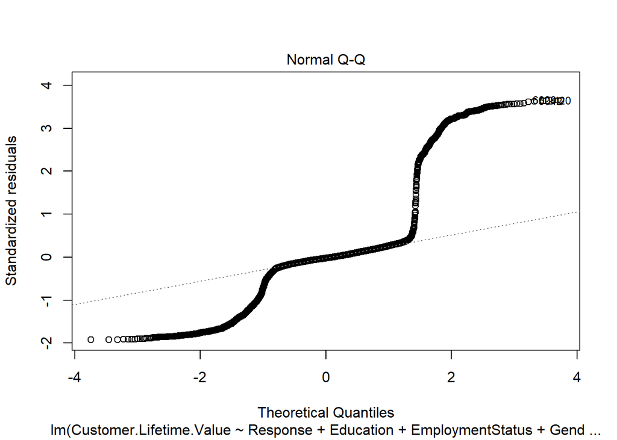

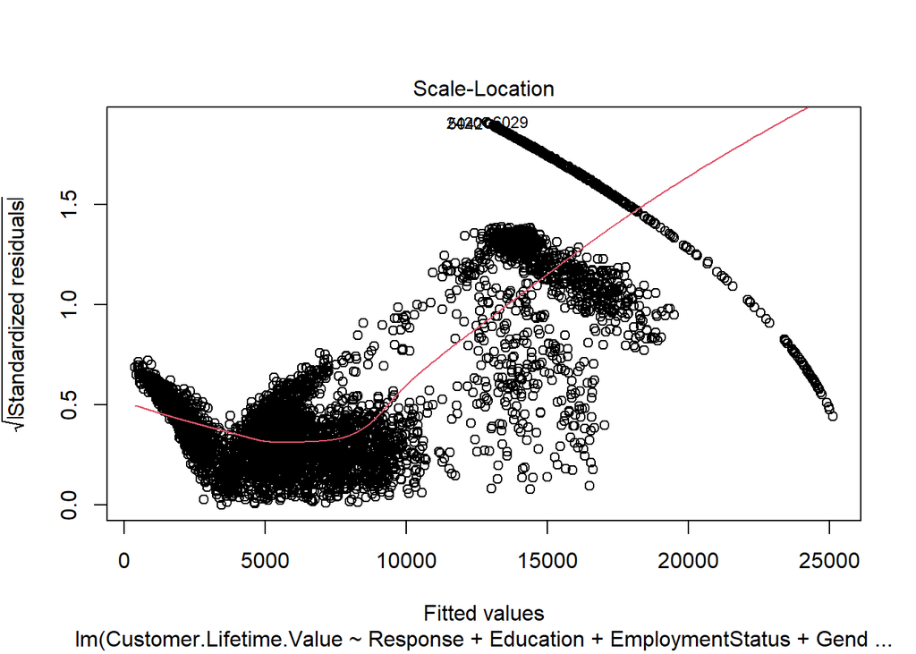

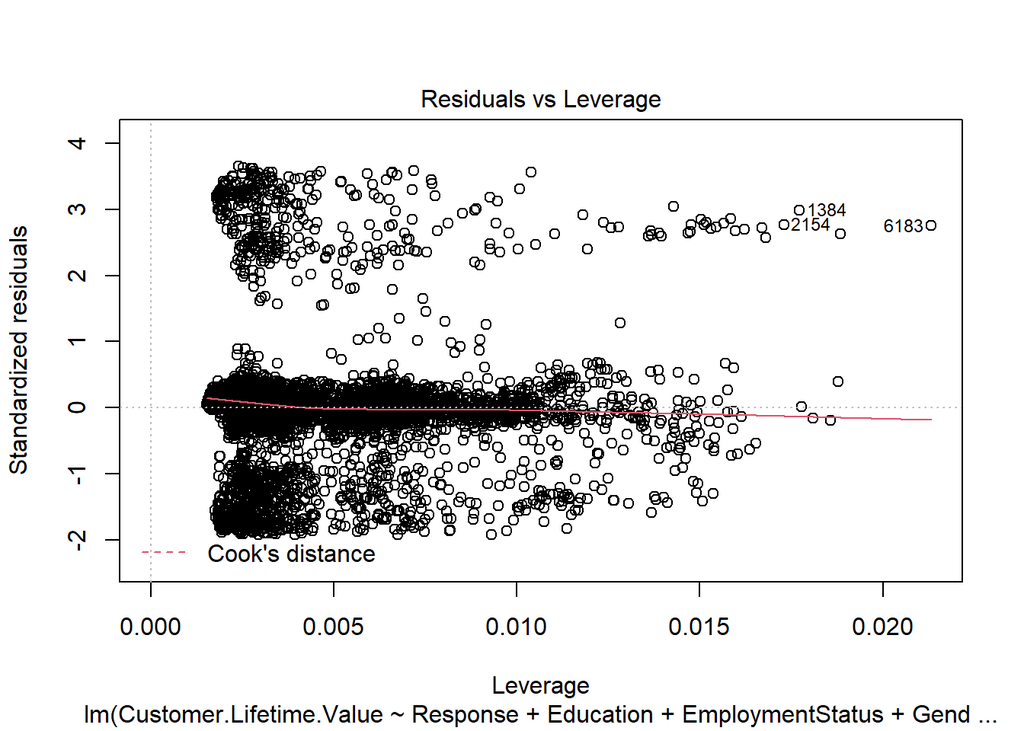

```r
plot(model4)
```

#### MODEL 5

Clustering methods like k mode and k means are used to group similar inputs. These clusters are then passed to a linear model. All the variables were used in this model. Here, adjusted R2 = 0.6871.

###### Features Selected -

- All variables from model1 and additional variables cat.clusters and num.clusters

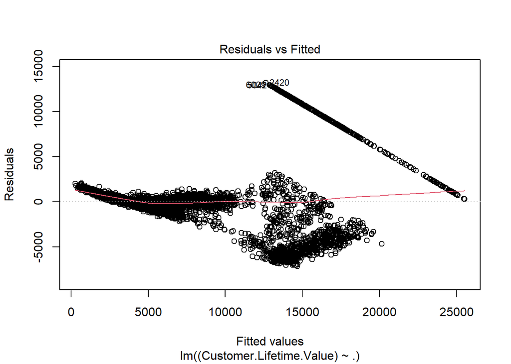

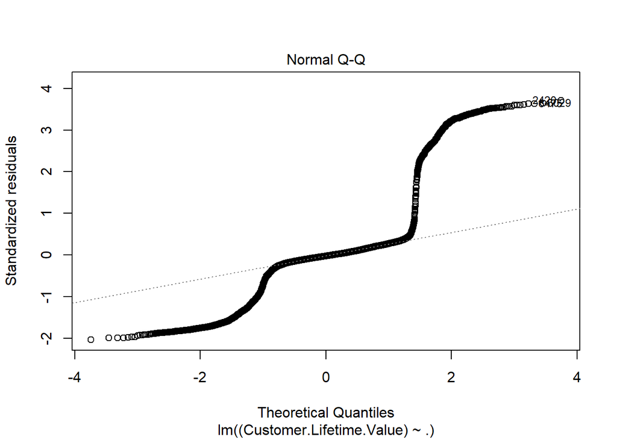

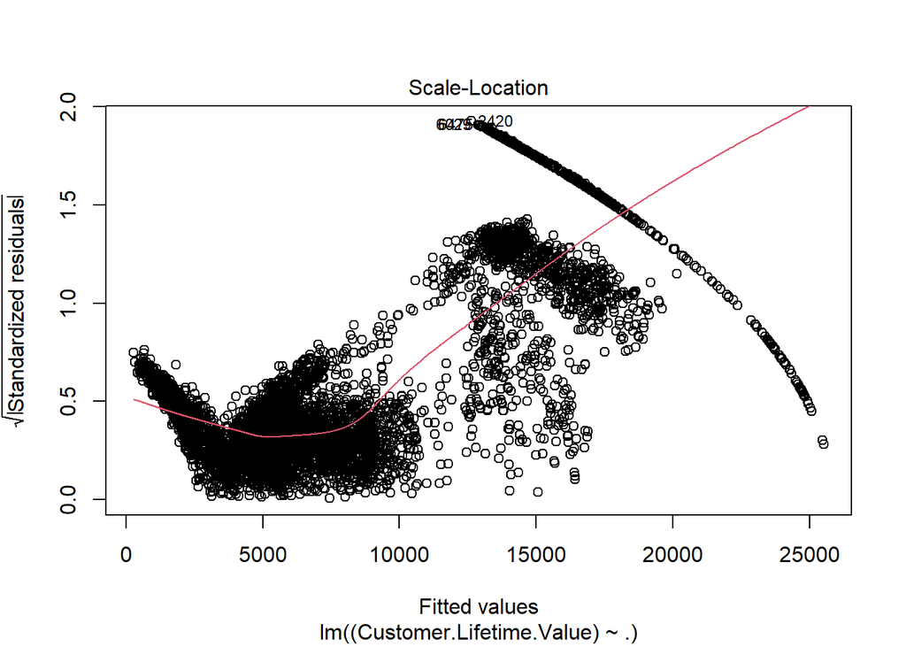

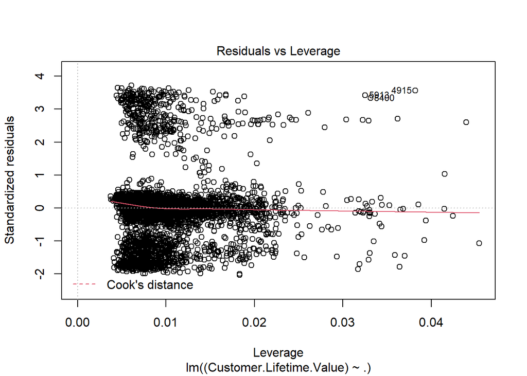

```r
plot(model5)
```

```r
rsquare(model5,df.train)
```

```
## [1] 0.6902594
```

```r
rsquare(model5,df.test)
```

```
## [1] 0.620297
```

#### MODEL 6

Variables for this model were selected by carrying out stepwise regression on the previous model. Here, adjusted R2 = 0.6878.

###### Features Selected -

- Coverage
- EmploymentStatus
- Gender
- Marital.Status
- Monthly.Premium.Auto
- Months.Since.Last.Claim
- Number.of.Open.Complaints
- Number.of.Policies
- Vehicle.Class

```r
rsquare(model6,df.train)
```

```
## [1] 0.689203
```

```r
rsquare(model6,df.test)
```

```
## [1] 0.6204036
```

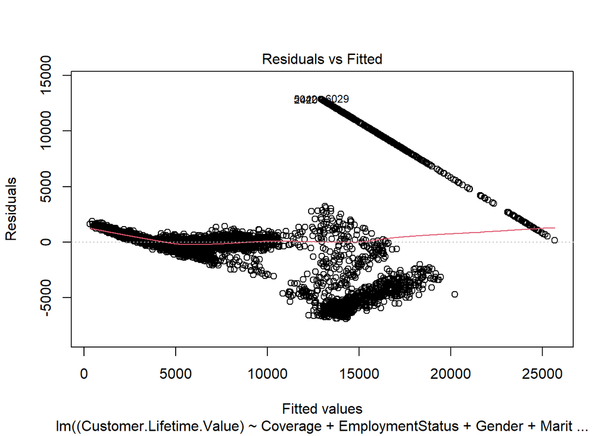

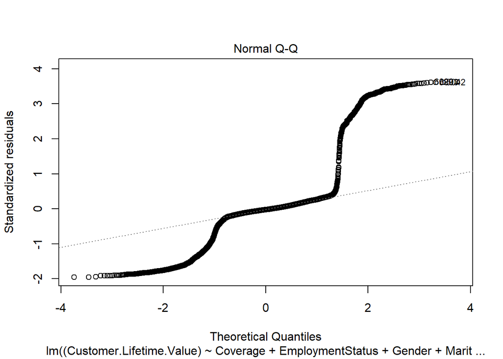

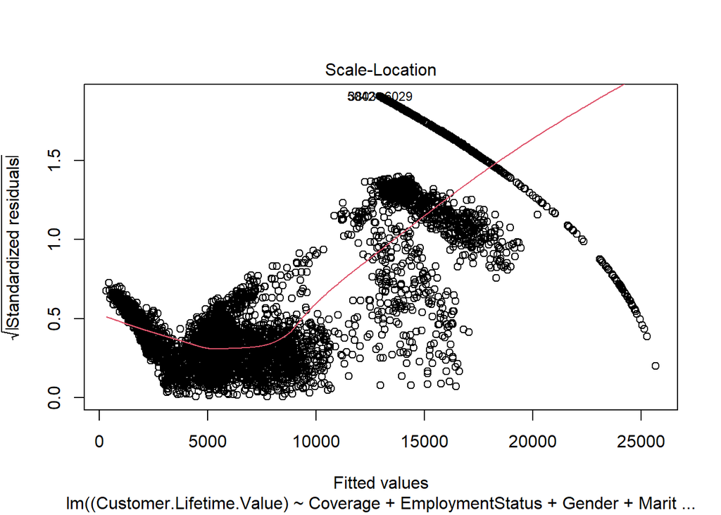

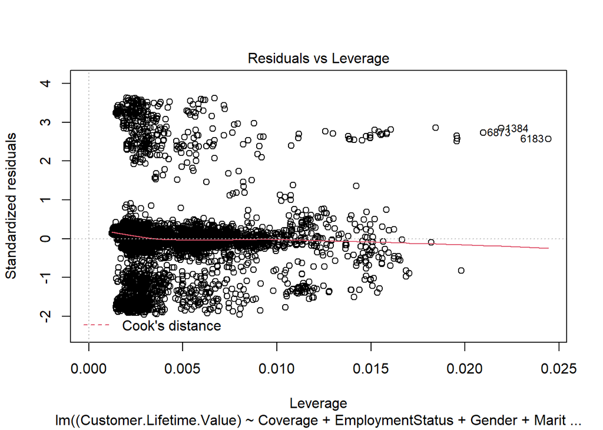

```r
plot(model6)
```

#### MODEL 7

In this model, an additional column was included where the square of Monthly Premium Auto was used. But the additional variable was found to be insignificant (p value > 0.05).

###### Features Selected -

- Coverage
- EmploymentStatus
- Gender
- Marital.Status
- Monthly.Premium.Auto
- Monthly.Premium.Auto**2
- Months.Since.Last.Claim
- Number.of.Open.Complaints
- Number.of.Policies
- Vehicle.Class

```r
rsquare(model7,df.train)
```

```
## [1] 0.6892117
```

```r
rsquare(model7,df.test)
```

```
## [1] 0.6202843
```

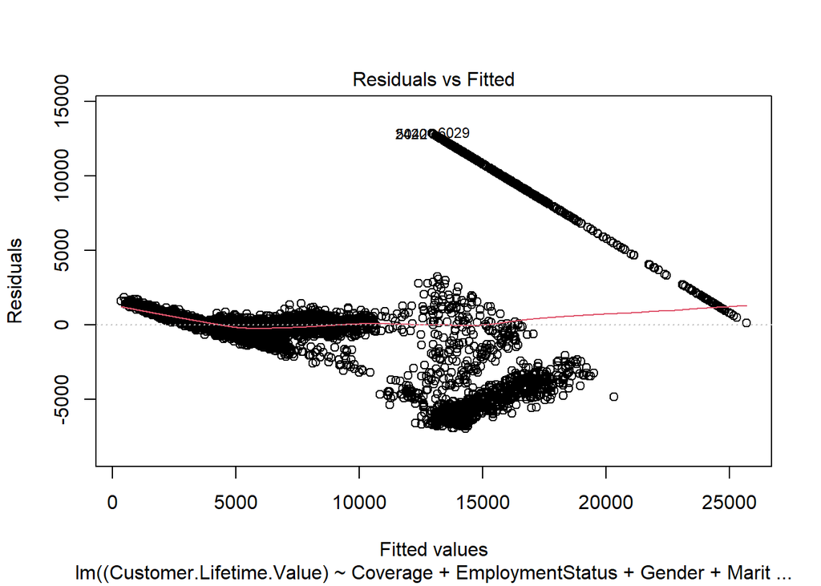

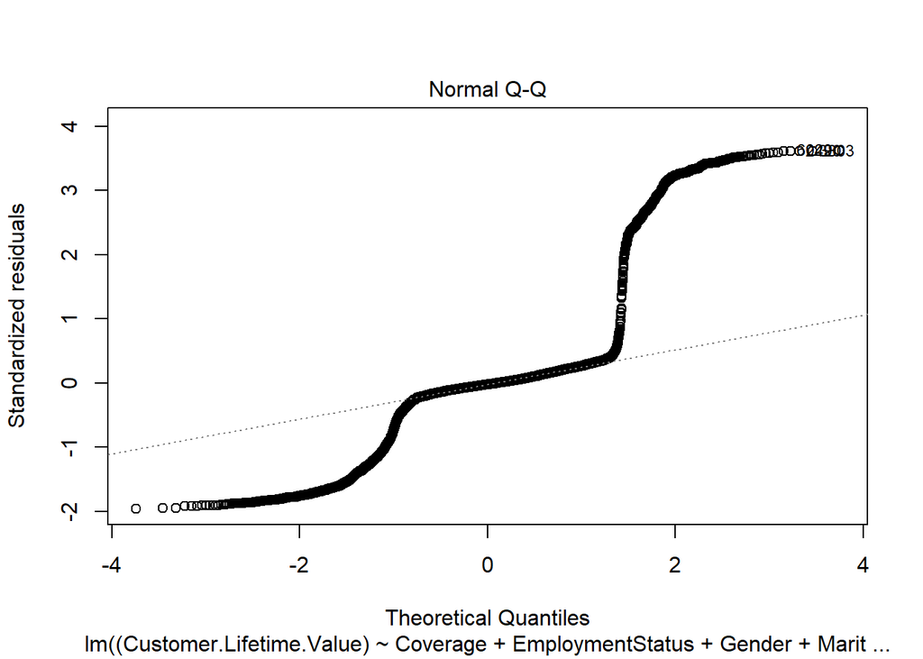

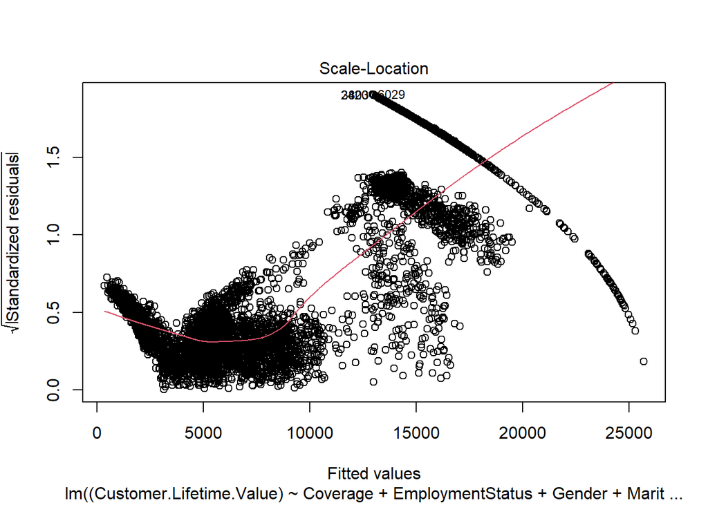

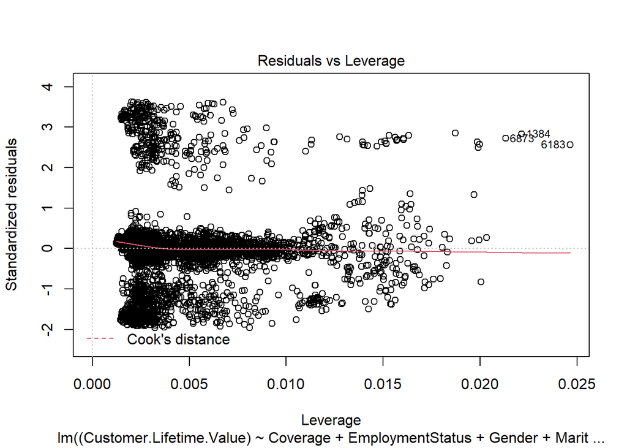

```r
plot(model7)
```

#### MODEL 8

We used Random forest regressor to model the data. It overfits our training dataset.

###### Features Selected -

- All the features in model1

```r
rsquare(model8,df.train)
```

```
## [1] 0.9462329
```

```r
rsquare(model8,df.test)
```

```
## [1] 0.6697807
```

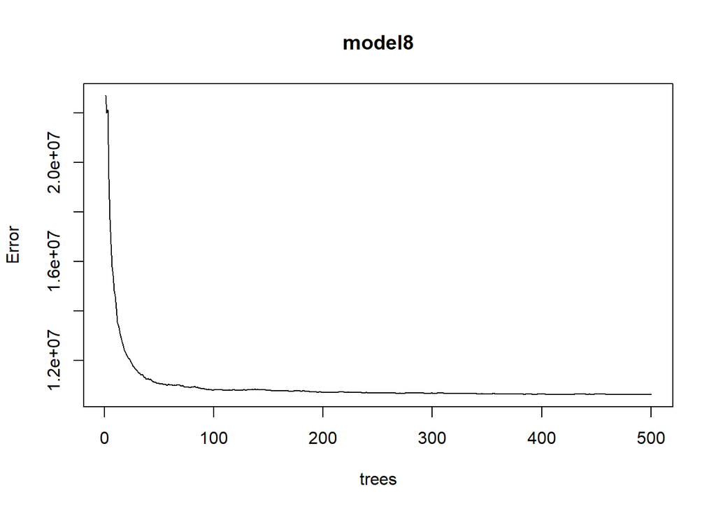

```r
plot(model8)
```

### MODEL PERFORMANCE OF FINAL MODEL

ASSESSING ACCURACY OF MODELS

Comparing all the models, we can see that adjusted R squared is highest for model 6. The result suggests that the variables can explain about 69% of variability in our clv data.

```r
model6 <- lm((Customer.Lifetime.Value)~
                 Coverage
               + EmploymentStatus
               + Gender
               + Marital.Status
               + Monthly.Premium.Auto
               + Months.Since.Last.Claim
               + Number.of.Open.Complaints
               + Number.of.Policies
               + Vehicle.Class
               ,data=df.train)


summary(model6)
```

```
##
## Call:
## lm(formula = (Customer.Lifetime.Value) ~ Coverage + EmploymentStatus +
##     Gender + Marital.Status + Monthly.Premium.Auto + Months.Since.Last.Claim +
##     Number.of.Open.Complaints + Number.of.Policies + Vehicle.Class,
##     data = df.train)
##
## Residuals:
##     Min      1Q  Median      3Q     Max
## -6941.0  -727.9   -88.0   562.8 12872.3
##
## Coefficients:
##                                Estimate Std. Error t value Pr(>|t|)
## (Intercept)                   -1758.155    526.872  -3.337 0.000853 ***
## CoverageExtended                447.763    167.109   2.679 0.007396 **
## CoveragePremium                 786.744    339.307   2.319 0.020449 *
## EmploymentStatusEmployed        798.445    234.257   3.408 0.000658 ***
## EmploymentStatusMedical Leave   633.570    316.586   2.001 0.045414 *
## EmploymentStatusRetired         474.181    354.734   1.337 0.181368
## EmploymentStatusUnemployed      226.525    251.236   0.902 0.367286
## GenderM                        -355.881     95.970  -3.708 0.000211 ***
## Marital.StatusMarried           -56.498    139.601  -0.405 0.685707
## Marital.StatusSingle           -378.835    161.164  -2.351 0.018778 *
## Monthly.Premium.Auto             45.209      6.573   6.878 6.75e-12 ***
## Months.Since.Last.Claim          12.130      4.787   2.534 0.011308 *
## Number.of.Open.Complaints      -173.240     51.729  -3.349 0.000816 ***
## Number.of.Policies2           12101.312    124.496  97.203  < 2e-16 ***
## Number.of.Policies3            3629.705    155.552  23.334  < 2e-16 ***
## Number.of.Policies4            3719.656    236.573  15.723  < 2e-16 ***
## Number.of.Policies5            3621.883    239.875  15.099  < 2e-16 ***
## Number.of.Policies6            3606.975    255.415  14.122  < 2e-16 ***
## Number.of.Policies7            3758.702    243.759  15.420  < 2e-16 ***
## Number.of.Policies8            3828.544    239.245  16.003  < 2e-16 ***
## Number.of.Policies9            3808.901    238.890  15.944  < 2e-16 ***
## Vehicle.ClassLuxury Car        4623.210    819.035   5.645 1.74e-08 ***
## Vehicle.ClassLuxury SUV        4756.869    797.964   5.961 2.66e-09 ***
## Vehicle.ClassSports Car        1528.365    365.480   4.182 2.94e-05 ***
## Vehicle.ClassSUV               1124.524    316.164   3.557 0.000379 ***
## Vehicle.ClassTwo-Door Car        71.283    125.120   0.570 0.568895
## ---
## Signif. codes:  0 '***' 0.001 '**' 0.01 '*' 0.05 '.' 0.1 ' ' 1
##
## Residual standard error: 3551 on 5501 degrees of freedom
## Multiple R-squared:  0.6892, Adjusted R-squared:  0.6878
## F-statistic: 487.9 on 25 and 5501 DF,  p-value: < 2.2e-16
```

```r
# CROSS VALIDATION

# Train the model
set.seed(123)
train.control <- trainControl(method = "cv", number = 10)

model6cv <- train(Customer.Lifetime.Value~
                 Coverage
               + EmploymentStatus
               + Gender
               + Marital.Status
               + Monthly.Premium.Auto
               + Months.Since.Last.Claim
               + Number.of.Open.Complaints
               + Number.of.Policies
               + Vehicle.Class ,data=df.train, method = "lm",
               trControl = train.control)

# Summarize the results
print(model6cv)
```

```
## Linear Regression
##
## 5527 samples
##    9 predictor
##
## No pre-processing
## Resampling: Cross-Validated (10 fold)
## Summary of sample sizes: 4973, 4974, 4975, 4975, 4974, 4973, ...
## Resampling results:
##
##   RMSE      Rsquared  MAE
##   3557.326  0.687139  2008.226
##
## Tuning parameter 'intercept' was held constant at a value of TRUE
```

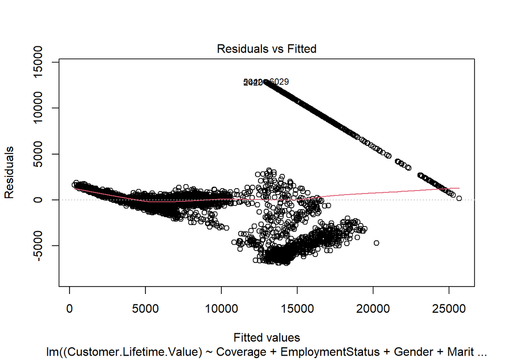

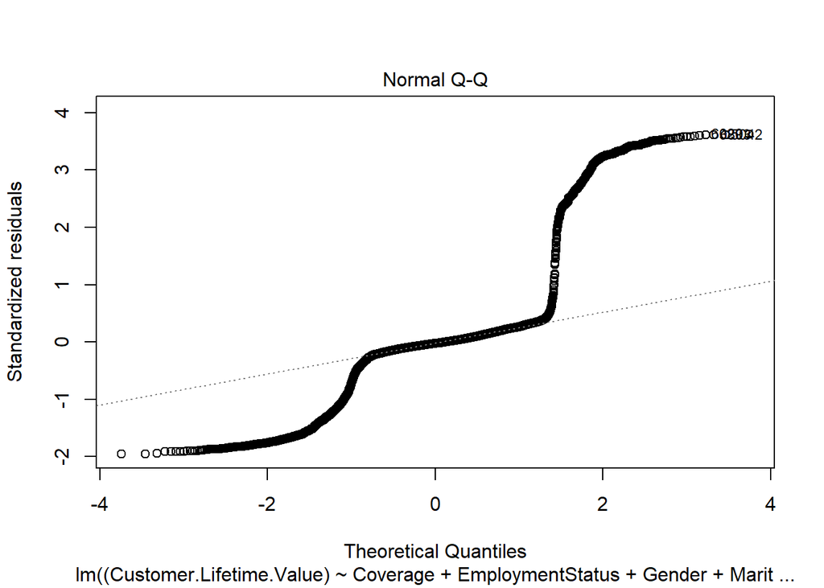

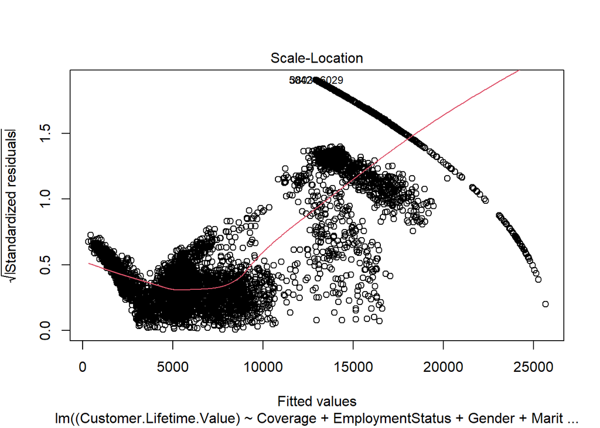

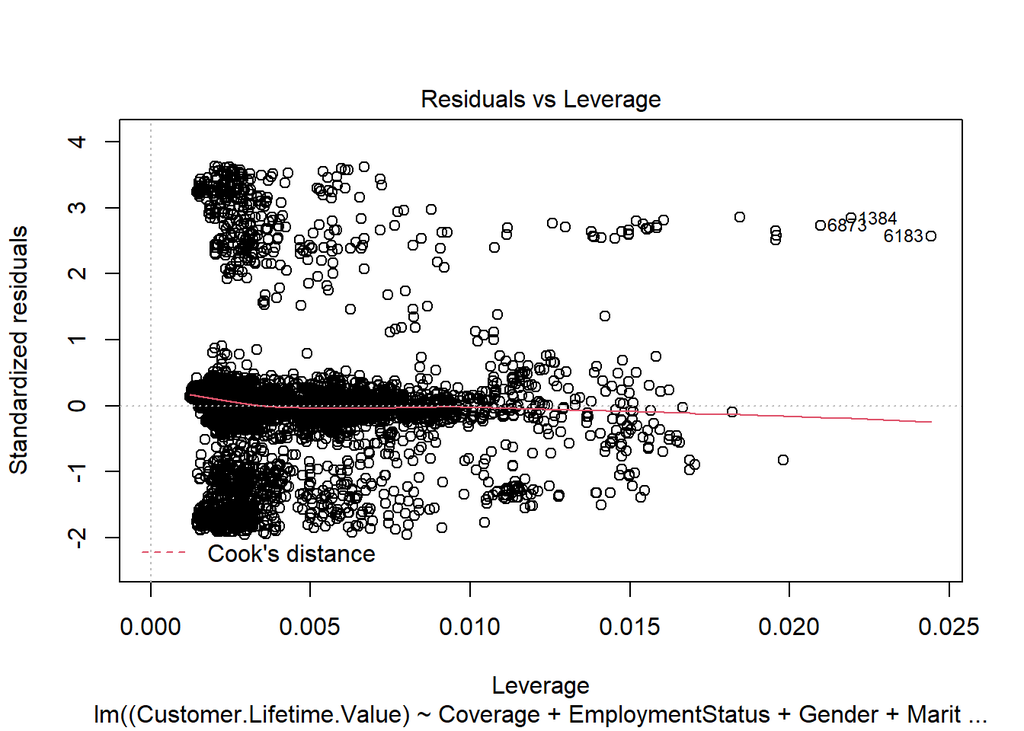

```r
plot(model6)
```

Graph 2: QQ plot - - Used to validate assumption of normal distribution in a dataset. - if the line is straight, then it implies a normal distribution. - The deviation from straight line implies absence of normality.

```r
model6 <- lm((Customer.Lifetime.Value)~
                 Coverage
               + EmploymentStatus
               + Gender
               + Marital.Status
               + Monthly.Premium.Auto
               + Months.Since.Last.Claim
               + Number.of.Open.Complaints
               + Number.of.Policies
               + Vehicle.Class
               ,data=df.train[-c(6183, 6873,1384),])


summary(model6)
```

```
##
## Call:
## lm(formula = (Customer.Lifetime.Value) ~ Coverage + EmploymentStatus +
##     Gender + Marital.Status + Monthly.Premium.Auto + Months.Since.Last.Claim +
##     Number.of.Open.Complaints + Number.of.Policies + Vehicle.Class,
##     data = df.train[-c(6183, 6873, 1384), ])
##
## Residuals:
##     Min      1Q  Median      3Q     Max
## -6948.3  -727.8   -88.5   561.3 12868.6
##
## Coefficients:
##                                Estimate Std. Error t value Pr(>|t|)
## (Intercept)                   -1758.904    526.771  -3.339 0.000846 ***
## CoverageExtended                445.559    167.082   2.667 0.007682 **
## CoveragePremium                 784.179    339.245   2.312 0.020840 *
## EmploymentStatusEmployed        800.382    234.215   3.417 0.000637 ***
## EmploymentStatusMedical Leave   633.743    316.525   2.002 0.045314 *
## EmploymentStatusRetired         474.756    354.666   1.339 0.180756
## EmploymentStatusUnemployed      227.228    251.188   0.905 0.365711
## GenderM                        -358.096     95.960  -3.732 0.000192 ***
## Marital.StatusMarried           -54.381    139.580  -0.390 0.696842
## Marital.StatusSingle           -378.146    161.134  -2.347 0.018972 *
## Monthly.Premium.Auto             45.221      6.572   6.881 6.60e-12 ***
## Months.Since.Last.Claim          12.154      4.786   2.539 0.011130 *
## Number.of.Open.Complaints      -173.746     51.720  -3.359 0.000786 ***
## Number.of.Policies2           12105.854    124.499  97.237  < 2e-16 ***
## Number.of.Policies3            3629.648    155.522  23.339  < 2e-16 ***
## Number.of.Policies4            3719.561    236.528  15.726  < 2e-16 ***
## Number.of.Policies5            3621.771    239.829  15.101  < 2e-16 ***
## Number.of.Policies6            3606.810    255.366  14.124  < 2e-16 ***
## Number.of.Policies7            3758.703    243.712  15.423  < 2e-16 ***
## Number.of.Policies8            3828.527    239.199  16.006  < 2e-16 ***
## Number.of.Policies9            3809.024    238.844  15.948  < 2e-16 ***
## Vehicle.ClassLuxury Car        4619.588    818.880   5.641 1.77e-08 ***
## Vehicle.ClassLuxury SUV        4753.634    797.813   5.958 2.71e-09 ***
## Vehicle.ClassSports Car        1525.593    365.414   4.175 3.03e-05 ***
## Vehicle.ClassSUV               1121.559    316.108   3.548 0.000391 ***
## Vehicle.ClassTwo-Door Car        68.901    125.103   0.551 0.581825
## ---
## Signif. codes:  0 '***' 0.001 '**' 0.01 '*' 0.05 '.' 0.1 ' ' 1
##
## Residual standard error: 3550 on 5500 degrees of freedom
## Multiple R-squared:  0.6894, Adjusted R-squared:  0.688
## F-statistic: 488.3 on 25 and 5500 DF,  p-value: < 2.2e-16
```

# Conclusions

#### Additions that would have help analysis:

1. Details regarding the type of policies when they had taken multiple policies.
2. Details about the frequency of claims Made would have assisted in the understanding of the CLV.
3. As there were a considerable number of clients who have taken policies, that are unemployment (with income = 0). Details on the fact that these clients had taken policies on the name of their guardians (Young adults/new drivers) would add on as to their target audience better understanding the CLV amount.

# References

http://www.sumsar.net/blog/2015/03/a-speed-comparison-between-flexible-linear-regression-alternatives-in-r/

http://r-statistics.co/Variable-Selection-and-Importance-With-R.html

https://r-statistics.co/Outlier-Treatment-With-R.html

http://www.sthda.com/english/articles/38-regression-model-validation/157-cross-validation-essentials-in-r/

https://www.tutorialspoint.com/r/r_random_forest.htm

https://www.gormanalysis.com/blog/r-introduction-to-factors-tutorial/

# Work Distributions

Though mentioned below are the division of tasks, each member of the team contributed towards each other’s task. Each of us had done personal EDA, feature engineering and initial model development. Of those the best were selected, further developed and reported.

Marion (20BDA04): Along with Gargi, developed the final structure of the Models and performance.

Bismi (20BDA07): Along with Lakshmi, developed the final structure of the EDA and Feature engineering. Compilation of the final report.

Lakshmi (20BDA09): Along with Bismi, developed the final structure of the EDA and Feature engineering. Compilation of the final report.

Glennis (20BDA24): Provided the final excerpt for the conclusions and additions to the concept.

Gargi (20BDA55): Along with Marion, developed the final structure of the Models and performance.

Ajay (20BDA64): Provided the base concept for the structure of the model. In addition also added the final excerpt of about CLV